# RandomForest approch with `caret` package and parallel training

onion

20170401

## Introduction

> - Data cleaning
> - Data exploration
> - Data slicing
> - Model fitting
> - Making submission

## 1.Data cleaning: loading data and imputing

First load the data and implement packages. Here I use `data.table` to manipulate the data. Combine train set and test set as a single full set.

```r
library(caret)
library(data.table)
library(ggplot2)
library(doParallel)
data=rbind(fread("data/train.csv"),fread("data/test.csv"),fill=T)
```

Then let’s find out the missing data. We calculate the number of `NA` in each column and also, noting that some character variables with some records equal to “”, we should take them into consideration too.

```r
colSums(sapply(data,is.na))
```

```
## PassengerId    Survived      Pclass        Name         Sex         Age
##           0         418           0           0           0         263
##       SibSp       Parch      Ticket        Fare       Cabin    Embarked
##           0           0           0           1           0           0
```

```r
sapply(data,FUN = function(x) length(which(x=="")))
```

```
## PassengerId    Survived      Pclass        Name         Sex         Age
##           0           0           0           0           0           0
##       SibSp       Parch      Ticket        Fare       Cabin    Embarked
##           0           0           0           0        1014           2
```

The “Embarked” is related to “Pclass” and “Fare”, therefore the missing “Embarked” might be “C” according to the boxplot of “Fare” by Pclass groups.

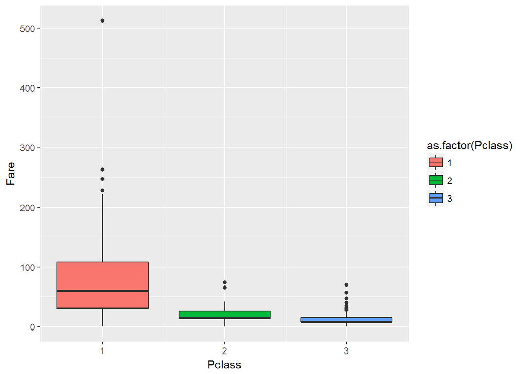

```r
ggplot(data,aes(x=Pclass,y=Fare,group=Pclass,fill=as.factor(Pclass)))+geom_boxplot()
```

```r
data[Embarked==""]
```

```
##    PassengerId Survived Pclass                                      Name
## 1:          62        1      1                       Icard, Miss. Amelie
## 2:         830        1      1 Stone, Mrs. George Nelson (Martha Evelyn)
##       Sex Age SibSp Parch Ticket Fare Cabin Embarked
## 1: female  38     0     0 113572   80   B28
## 2: female  62     0     0 113572   80   B28
```

```r
data[Embarked=="",Embarked:="C"]
```

```
##       PassengerId Survived Pclass
##    1:           1        0      3
##    2:           2        1      1
##    3:           3        1      3
##    4:           4        1      1
##    5:           5        0      3
##   ---
## 1305:        1305       NA      3
## 1306:        1306       NA      1
## 1307:        1307       NA      3
## 1308:        1308       NA      3
## 1309:        1309       NA      3
##                                                      Name    Sex  Age
##    1:                             Braund, Mr. Owen Harris   male 22.0
##    2: Cumings, Mrs. John Bradley (Florence Briggs Thayer) female 38.0
```

[output cut: 21 more lines]

The missing “Fare” can be imputed by the mean of records with same “Embarked” and “Pclass”.

```r
data[is.na(Fare),Fare:=data[Pclass==data[is.na(Fare),Pclass]&&Embarked==data[is.na(Fare),Embarked],mean(Fare,na.rm=T)]]
```

```
##       PassengerId Survived Pclass
##    1:           1        0      3
##    2:           2        1      1
##    3:           3        1      3
##    4:           4        1      1
##    5:           5        0      3
##   ---
## 1305:        1305       NA      3
## 1306:        1306       NA      1
## 1307:        1307       NA      3
## 1308:        1308       NA      3
## 1309:        1309       NA      3
##                                                      Name    Sex  Age
##    1:                             Braund, Mr. Owen Harris   male 22.0
##    2: Cumings, Mrs. John Bradley (Florence Briggs Thayer) female 38.0
```

[output cut: 21 more lines]

As for “Age”, the information hide within the title in “Name”, such as “Mr.”, “Mrs.”. We infer “Age” by the mean of people with same title.

```r
getTitle=function(s){
  reg=sapply(s,FUN = function(x) return(gregexpr("\\s\\S+\\.",x)))
  return(sapply(1:length(s),FUN=function(x) substr(s[x],reg[x][[1]]+1,reg[x][[1]]+attr(reg[x][[1]],"match.length")-1)))
}
data[,`:=`(Title=getTitle(Name))]
```

```
##       PassengerId Survived Pclass
##    1:           1        0      3
##    2:           2        1      1
##    3:           3        1      3
##    4:           4        1      1
##    5:           5        0      3
##   ---
## 1305:        1305       NA      3
## 1306:        1306       NA      1
## 1307:        1307       NA      3
## 1308:        1308       NA      3
## 1309:        1309       NA      3
##                                                      Name    Sex  Age
##    1:                             Braund, Mr. Owen Harris   male 22.0
##    2: Cumings, Mrs. John Bradley (Florence Briggs Thayer) female 38.0
```

[output cut: 21 more lines]

```r
data[,gpAge:=mean(Age,na.rm=T),by=Title]
```

```
##       PassengerId Survived Pclass
##    1:           1        0      3
##    2:           2        1      1
##    3:           3        1      3
##    4:           4        1      1
##    5:           5        0      3
##   ---
## 1305:        1305       NA      3
## 1306:        1306       NA      1
## 1307:        1307       NA      3
## 1308:        1308       NA      3
## 1309:        1309       NA      3
##                                                      Name    Sex  Age
##    1:                             Braund, Mr. Owen Harris   male 22.0
##    2: Cumings, Mrs. John Bradley (Florence Briggs Thayer) female 38.0
```

[output cut: 33 more lines]

```r
data[is.na(Age),Age:=gpAge,]
```

```
##       PassengerId Survived Pclass
##    1:           1        0      3
##    2:           2        1      1
##    3:           3        1      3
##    4:           4        1      1
##    5:           5        0      3
##   ---
## 1305:        1305       NA      3
## 1306:        1306       NA      1
## 1307:        1307       NA      3
## 1308:        1308       NA      3
## 1309:        1309       NA      3
##                                                      Name    Sex       Age
##    1:                             Braund, Mr. Owen Harris   male 22.000000
##    2: Cumings, Mrs. John Bradley (Florence Briggs Thayer) female 38.000000
```

[output cut: 33 more lines]

## 2.Data exploration: feature engineering

There exists a surviving penalty for adults according to the density plot. We create new variable “Child” which contains 0 for adults and 1 for children. Sum up “SibSp” and “Parch” to create a variable describing the family size. Then transform categories variables to factors.

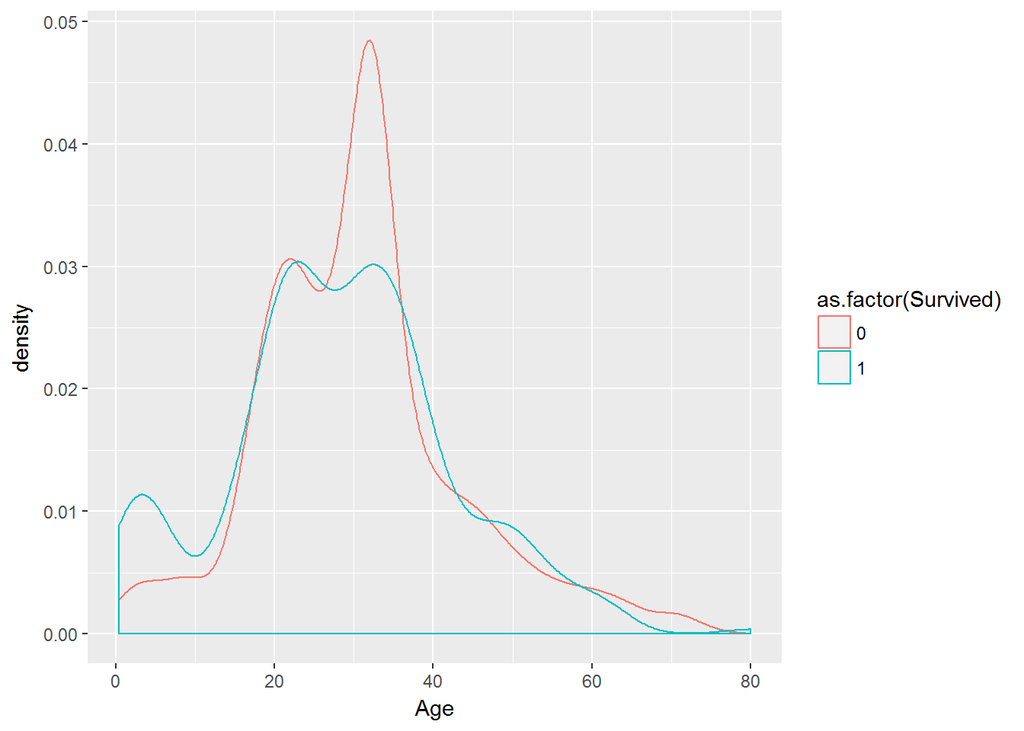

```r
ggplot(data=data[!is.na(Survived)],aes(x=Age,colour=as.factor(Survived)))+geom_density()
```

```r
table(data[(!is.na(Survived))][Age<18,Survived])
```

```
##
##  0  1
## 54 63
```

```r
table(data[(!is.na(Survived))][Age>=18,Survived])
```

```
##
##   0   1
## 495 279
```

```r
data[,`:=`(FamilySize=SibSp+Parch+1,Child=rep(0,.N))]
```

```
##       PassengerId Survived Pclass
##    1:           1        0      3
##    2:           2        1      1
##    3:           3        1      3
##    4:           4        1      1
##    5:           5        0      3
##   ---
## 1305:        1305       NA      3
## 1306:        1306       NA      1
## 1307:        1307       NA      3
## 1308:        1308       NA      3
## 1309:        1309       NA      3
##                                                      Name    Sex       Age
##    1:                             Braund, Mr. Owen Harris   male 22.000000
##    2: Cumings, Mrs. John Bradley (Florence Briggs Thayer) female 38.000000
```

[output cut: 33 more lines]

```r
data[Age<18,Child:=1]
```

```
##       PassengerId Survived Pclass
##    1:           1        0      3
##    2:           2        1      1
##    3:           3        1      3
##    4:           4        1      1
##    5:           5        0      3
##   ---
## 1305:        1305       NA      3
## 1306:        1306       NA      1
## 1307:        1307       NA      3
## 1308:        1308       NA      3
## 1309:        1309       NA      3
##                                                      Name    Sex       Age
##    1:                             Braund, Mr. Owen Harris   male 22.000000
##    2: Cumings, Mrs. John Bradley (Florence Briggs Thayer) female 38.000000
```

[output cut: 33 more lines]

```r
data[,c("Survived","Pclass","Sex","Embarked","Child")]=lapply(data[,c("Survived","Pclass","Sex","Embarked","Title","Child")], function(x) as.factor(x))
```

## 3.Data slicing

In order to choose the best model, we divide the train set into two sets: `training` for training the model and `testing` for validating. The proportion of records in `training` is 75%.

```r
train=data[!is.na(Survived)]
test=data[is.na(Survived)]
set.seed(1)
inTrain=createDataPartition(y=train[,Survived],p=0.75,list=FALSE)
training=train[inTrain,]
testing=train[-inTrain,]
```

## 4.Model fitting

We choose randomForest as the model. For faster training, we use `doParallel` package to accelerate the computing by multicores.

```r
cluster <- makeCluster(detectCores() - 1)
registerDoParallel(cluster)
fitControl <- trainControl(allowParallel = TRUE)
set.seed(1)
modelFit=train(Survived~Pclass+Sex+Age+SibSp+Parch+Fare+Embarked+FamilySize+Child,
               method="rf",data=training,trControl = fitControl)
stopCluster(cluster)
registerDoSEQ()
modelFit
```

```
## Random Forest
##
## 669 samples
##   9 predictor
##   2 classes: '0', '1'
##
## No pre-processing
## Resampling: Bootstrapped (25 reps)
## Summary of sample sizes: 669, 669, 669, 669, 669, 669, ...
## Resampling results across tuning parameters:
##
##   mtry  Accuracy   Kappa
##    2    0.8299768  0.6307770
##   14    0.8218920  0.6188885
##   27    0.7995452  0.5749760
##
## Accuracy was used to select the optimal model using  the largest value.
## The final value used for the model was mtry = 2.
```

How about the performance in `testing`?

```r
confusionMatrix(testing$Survived,predict(modelFit,testing))
```

```
## Confusion Matrix and Statistics
##
##           Reference
## Prediction   0   1
##          0 116  21
##          1  28  57
##
##                Accuracy : 0.7793
##                  95% CI : (0.7189, 0.832)
##     No Information Rate : 0.6486
##     P-Value [Acc > NIR] : 1.675e-05
##
##                   Kappa : 0.5255
##  Mcnemar's Test P-Value : 0.3914
##
##             Sensitivity : 0.8056
##             Specificity : 0.7308
##          Pos Pred Value : 0.8467
##          Neg Pred Value : 0.6706
##              Prevalence : 0.6486
##          Detection Rate : 0.5225
##    Detection Prevalence : 0.6171
##       Balanced Accuracy : 0.7682
##
##        'Positive' Class : 0
##
```

## 5.Making submission

```r
cluster <- makeCluster(detectCores() - 1)
registerDoParallel(cluster)
fitControl <- trainControl(allowParallel = TRUE)
set.seed(1)
modelFit=train(Survived~Pclass+Sex+Age+SibSp+Parch+Fare+Embarked+FamilySize+Child,
               method="rf",data=train,trControl = fitControl)
stopCluster(cluster)
registerDoSEQ()
# write submission file
submit=test[,.(PassengerId)]
submit[,`:=`(Survived=predict(modelFit,test))]
```

```
##      PassengerId Survived
##   1:         892        0
##   2:         893        1
##   3:         894        0
##   4:         895        0
##   5:         896        1
##  ---
## 414:        1305        0
## 415:        1306        1
## 416:        1307        0
## 417:        1308        0
## 418:        1309        1
```